# bone_ANOVAs

Tom

May 11, 2018

# Load Libraries

```r
library(tidyverse)
library(datasets)
library(writexl)
library(broom)
```

## Generate data sets

The toothgrowth dataset has two treatments (Vitamin C and OJ, with 3 doses), doesn’t EXACTLY match your criteria

```r
# Generate the data, creating multiple fake Dependent Variables
bone_df <- as.tibble(ToothGrowth) %>%
    mutate(dose = factor(dose),
           molars = len*2,
           crunchers = len*3,
           canines = len*3.14,
           femur = len*37) %>%
    select(supp, dose, everything())

# for playing around with if you wanna run ONE aov and tukey.
bone_len <- bone_df %>%
    select(dose, supp, len)

bone_molars <- bone_df %>%
    select(dose, supp, molars)

bone_crunchers <- bone_df %>%
    select(dose, supp, crunchers)
```

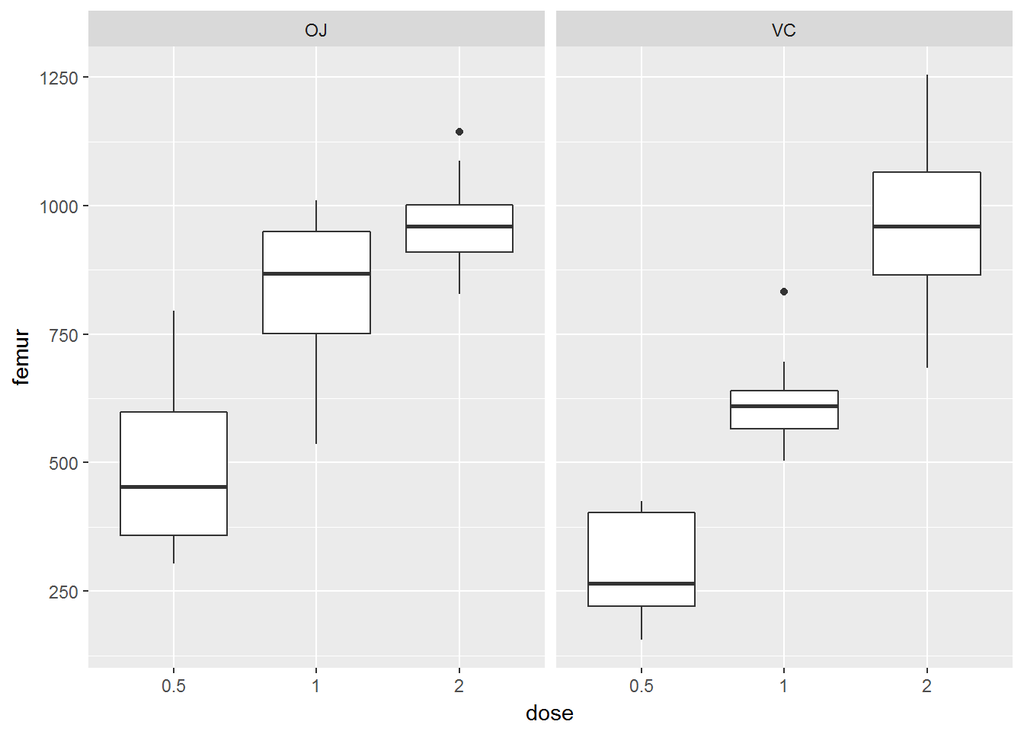

```r
# exploratory graph
bone_df %>%
    ggplot(aes(x = dose, y = femur)) +
    geom_boxplot() +
    facet_grid(~supp)
```

## Setup and run the ANOVAs

Notice I am selecting ALL the dependent variables since I have one wide dataset with unchanging factors. We do this with our “master” data file that has all of our dependent variables in an individual column with matching factors/ids. This is also how I set up the dataset for this experiment. You can run how ever many dependent variables you wanted as long as they are IN the dataset.

```r
# select the depedent variables of interest(exclude the factors)
all_anova <- bone_df %>%
    select(len:femur) %>%
    map(~ aov(lm(.x ~ supp * dose, data = bone_df)))

all_anova
```

```
## $len
## Call:
##    aov(formula = lm(.x ~ supp * dose, data = bone_df))
##
## Terms:
##                     supp     dose supp:dose Residuals
## Sum of Squares   205.350 2426.434   108.319   712.106
## Deg. of Freedom        1        2         2        54
##
## Residual standard error: 3.631411
## Estimated effects may be unbalanced
##
## $molars
## Call:
##    aov(formula = lm(.x ~ supp * dose, data = bone_df))
##
## Terms:
##                     supp     dose supp:dose Residuals
## Sum of Squares   821.400 9705.737   433.276  2848.424
## Deg. of Freedom        1        2         2        54
##
## Residual standard error: 7.262823
## Estimated effects may be unbalanced
##
## $crunchers
## Call:
##    aov(formula = lm(.x ~ supp * dose, data = bone_df))
##
## Terms:
##                      supp      dose supp:dose Residuals
## Sum of Squares   1848.150 21837.909   974.871  6408.954
## Deg. of Freedom         1         2         2        54
##
## Residual standard error: 10.89423
## Estimated effects may be unbalanced
##
## $canines
## Call:
##    aov(formula = lm(.x ~ supp * dose, data = bone_df))
##
## Terms:
##                      supp      dose supp:dose Residuals
## Sum of Squares   2024.669 23923.672  1067.982  7021.080
## Deg. of Freedom         1         2         2        54
##
## Residual standard error: 11.40263
## Estimated effects may be unbalanced
##
## $femur
## Call:
##    aov(formula = lm(.x ~ supp * dose, data = bone_df))
##
## Terms:
##                    supp    dose supp:dose Residuals
## Sum of Squares   281124 3321789    148289    974873
## Deg. of Freedom       1       2         2        54
##
## Residual standard error: 134.3622
## Estimated effects may be unbalanced
```

```r
# notice there is a list of dataframes, where each dataset is named after
# the initial column name. You could select from this list of dfs with all_anova$name

# and the broom::tidy output as example
tidy(all_anova$len)
```

```
##        term df    sumsq     meansq statistic      p.value
## 1      supp  1  205.350  205.35000 15.571979 2.311828e-04
## 2      dose  2 2426.434 1213.21717 91.999965 4.046291e-18
## 3 supp:dose  2  108.319   54.15950  4.106991 2.186027e-02
## 4 Residuals 54  712.106   13.18715        NA           NA
```

```r
# quick chec to show you what the TukeyHSD looks like
# we need to specify the interaction with which =
tidy(TukeyHSD(all_anova$len, which = "supp:dose"))
```

```
##         term    comparison estimate   conf.low  conf.high  adj.p.value
## 1  supp:dose VC:0.5-OJ:0.5    -5.25 -10.048124 -0.4518762 2.425209e-02
## 2  supp:dose   OJ:1-OJ:0.5     9.47   4.671876 14.2681238 4.612304e-06
## 3  supp:dose   VC:1-OJ:0.5     3.54  -1.258124  8.3381238 2.640208e-01
## 4  supp:dose   OJ:2-OJ:0.5    12.83   8.031876 17.6281238 2.125153e-09
## 5  supp:dose   VC:2-OJ:0.5    12.91   8.111876 17.7081238 1.769939e-09
## 6  supp:dose   OJ:1-VC:0.5    14.72   9.921876 19.5181238 2.985967e-11
## 7  supp:dose   VC:1-VC:0.5     8.79   3.991876 13.5881238 2.100948e-05
## 8  supp:dose   OJ:2-VC:0.5    18.08  13.281876 22.8781238 4.855005e-13
## 9  supp:dose   VC:2-VC:0.5    18.16  13.361876 22.9581238 4.821699e-13
## 10 supp:dose     VC:1-OJ:1    -5.93 -10.728124 -1.1318762 7.393032e-03
## 11 supp:dose     OJ:2-OJ:1     3.36  -1.438124  8.1581238 3.187361e-01
## 12 supp:dose     VC:2-OJ:1     3.44  -1.358124  8.2381238 2.936430e-01
## 13 supp:dose     OJ:2-VC:1     9.29   4.491876 14.0881238 6.908163e-06
## 14 supp:dose     VC:2-VC:1     9.37   4.571876 14.1681238 5.774013e-06
## 15 supp:dose     VC:2-OJ:2     0.08  -4.718124  4.8781238 1.000000e+00
```

We can now do a few things! I map broom::tidy() to get a nice clean output, round p value to 5 decimal places, and generate a “SIG” or blank if not significant. You can either stack the dataframe with bind_rows and then save as a .csv, .xlsx, or even just keep as a RDS file.

```r
# this does all the nice things and ends up with one LONG dataframe
# with a label for each set of main effects/interactions/residuals.
all_anova %>%
    map(., broom::tidy) %>%
    map(~ mutate(.x, p.value = round(p.value, 5))) %>%
    map( ~ mutate(.x, sig = case_when(p.value <= 0.05 ~ "SIG",
                                  p.value > 0.05 ~ ""))) %>%
    bind_rows(.id = "source")
```

```
##       source      term df       sumsq       meansq statistic p.value  sig
## 1        len      supp  1     205.350 2.053500e+02 15.571979 0.00023  SIG
## 2        len      dose  2    2426.434 1.213217e+03 91.999965 0.00000  SIG
## 3        len supp:dose  2     108.319 5.415950e+01  4.106991 0.02186  SIG
## 4        len Residuals 54     712.106 1.318715e+01        NA      NA <NA>
## 5     molars      supp  1     821.400 8.214000e+02 15.571979 0.00023  SIG
## 6     molars      dose  2    9705.737 4.852869e+03 91.999965 0.00000  SIG
## 7     molars supp:dose  2     433.276 2.166380e+02  4.106991 0.02186  SIG
## 8     molars Residuals 54    2848.424 5.274859e+01        NA      NA <NA>
## 9  crunchers      supp  1    1848.150 1.848150e+03 15.571979 0.00023  SIG
## 10 crunchers      dose  2   21837.909 1.091895e+04 91.999965 0.00000  SIG
## 11 crunchers supp:dose  2     974.871 4.874355e+02  4.106991 0.02186  SIG
## 12 crunchers Residuals 54    6408.954 1.186843e+02        NA      NA <NA>
## 13   canines      supp  1    2024.669 2.024669e+03 15.571979 0.00023  SIG
## 14   canines      dose  2   23923.672 1.196184e+04 91.999965 0.00000  SIG
## 15   canines supp:dose  2    1067.982 5.339910e+02  4.106991 0.02186  SIG
## 16   canines Residuals 54    7021.080 1.300200e+02        NA      NA <NA>
## 17     femur      supp  1  281124.150 2.811242e+05 15.571979 0.00023  SIG
## 18     femur      dose  2 3321788.602 1.660894e+06 91.999965 0.00000  SIG
## 19     femur supp:dose  2  148288.711 7.414436e+04  4.106991 0.02186  SIG
## 20     femur Residuals 54  974873.114 1.805321e+04        NA      NA <NA>
```

You can do the same thing as above with a `map_dfr` call as well, just make sure to use `.id = "source"` so that you keep the names from list of dataframes.

```r
all_anova %>%
    map(., broom::tidy) %>%
    map(~ mutate(.x, p.value = round(p.value, 5))) %>%
    map_dfr(~ mutate(.x, sig = case_when(p.value <= 0.05 ~ "SIG",
                                  p.value > 0.05 ~ "")), .id = "source")
```

[output not shown]

Alternatively I save to indivdual tabs of an excel file, as this is what my boss typically wants to see. Since this is a named list of dataframes, we get nice named tabs on the excel sheet.

```r
# this does all the nice things and ends up writing the list of dataframes
# to individuals tabs of an excel file
all_anova %>%
    map(., broom::tidy) %>% # notice that map(., tidy) is same as map(~ tidy(.))
    map(~ mutate(.x, p.value = round(p.value, 5))) %>%
    map(~ mutate(.x, sig = case_when(p.value <= 0.05 ~ "SIG",
                                  p.value > 0.05 ~ ""))) %>%
    writexl::write_xlsx(., "bone_anovas_type3.xlsx")
```

```
## [1] "C:\\Users\\30268\\Documents\\bone_ANOVA\\bone_anovas_type3.xlsx"
```

## Tukey post-hocs

Now that we have our ANOVAs taken care of, we can run our post-hocs on the ANOVAs. You can either bind into one LONG dataframe (like before w/ anova), or you can bind columns with `map_dfc`, or keep as a list and write to excel.

```r
# long dataframe
all_anova %>%
    map(~ tidy(TukeyHSD(., which = 'supp:dose'))) %>%
    bind_rows(.id = "source")
```

```
##       source      term    comparison  estimate    conf.low   conf.high
## 1        len supp:dose VC:0.5-OJ:0.5   -5.2500  -10.048124  -0.4518762
## 2        len supp:dose   OJ:1-OJ:0.5    9.4700    4.671876  14.2681238
## 3        len supp:dose   VC:1-OJ:0.5    3.5400   -1.258124   8.3381238
## 4        len supp:dose   OJ:2-OJ:0.5   12.8300    8.031876  17.6281238
## 5        len supp:dose   VC:2-OJ:0.5   12.9100    8.111876  17.7081238
## 6        len supp:dose   OJ:1-VC:0.5   14.7200    9.921876  19.5181238
## 7        len supp:dose   VC:1-VC:0.5    8.7900    3.991876  13.5881238
## 8        len supp:dose   OJ:2-VC:0.5   18.0800   13.281876  22.8781238
## 9        len supp:dose   VC:2-VC:0.5   18.1600   13.361876  22.9581238
## 10       len supp:dose     VC:1-OJ:1   -5.9300  -10.728124  -1.1318762
## 11       len supp:dose     OJ:2-OJ:1    3.3600   -1.438124   8.1581238
## 12       len supp:dose     VC:2-OJ:1    3.4400   -1.358124   8.2381238
## 13       len supp:dose     OJ:2-VC:1    9.2900    4.491876  14.0881238
## 14       len supp:dose     VC:2-VC:1    9.3700    4.571876  14.1681238
```

[output cut: 137 more lines]

```r
# wide - less than ideal as I don't know a way to generate proper names
# it just will add a number to each of the columns.
all_anova %>%
    map_dfc(~ tidy(TukeyHSD(., which = 'supp:dose')))
```

```
##         term    comparison estimate   conf.low  conf.high  adj.p.value
## 1  supp:dose VC:0.5-OJ:0.5    -5.25 -10.048124 -0.4518762 2.425209e-02
## 2  supp:dose   OJ:1-OJ:0.5     9.47   4.671876 14.2681238 4.612304e-06
## 3  supp:dose   VC:1-OJ:0.5     3.54  -1.258124  8.3381238 2.640208e-01
## 4  supp:dose   OJ:2-OJ:0.5    12.83   8.031876 17.6281238 2.125153e-09
## 5  supp:dose   VC:2-OJ:0.5    12.91   8.111876 17.7081238 1.769939e-09
## 6  supp:dose   OJ:1-VC:0.5    14.72   9.921876 19.5181238 2.985967e-11
## 7  supp:dose   VC:1-VC:0.5     8.79   3.991876 13.5881238 2.100948e-05
## 8  supp:dose   OJ:2-VC:0.5    18.08  13.281876 22.8781238 4.855005e-13
## 9  supp:dose   VC:2-VC:0.5    18.16  13.361876 22.9581238 4.821699e-13
## 10 supp:dose     VC:1-OJ:1    -5.93 -10.728124 -1.1318762 7.393032e-03
## 11 supp:dose     OJ:2-OJ:1     3.36  -1.438124  8.1581238 3.187361e-01
## 12 supp:dose     VC:2-OJ:1     3.44  -1.358124  8.2381238 2.936430e-01
## 13 supp:dose     OJ:2-VC:1     9.29   4.491876 14.0881238 6.908163e-06
## 14 supp:dose     VC:2-VC:1     9.37   4.571876 14.1681238 5.774013e-06
```

[output cut: 65 more lines]

```r
# write to excel
all_anova %>%
    map(~ tidy(TukeyHSD(., which = 'supp:dose'))) %>%
    writexl::write_xlsx(., "tidy_tukey.xlsx")
```

```
## [1] "C:\\Users\\30268\\Documents\\bone_ANOVA\\tidy_tukey.xlsx"
```